# Magma Evolution: Differentiation, Fractional Crystallization, Mixing, and Contamination

Dr. Ahmad Redaa

2024-09-09

# Objectives:

- Understand the processes that drive magma evolution.
- Explore how magmas differentiate through fractional crystallization.
- Discuss the roles of magma mixing and contamination in altering magma composition.
- Examine the impact of these processes on the formation of igneous rocks, either in intrusive plutons or volcanic settings.

# Magma Evolution

## Definitions:

- Magma: Molten rock material formed beneath the Earth’s surface.
- Magma Evolution: The process by which magma changes its composition and properties as it moves through the Earth’s crust and mantle.
- Evolution occurs as magma cools, crystallizes, and interacts with surrounding materials.

## Key Processes of Magma Evolution

1. Fractional Crystallization  
   - The crystallization of minerals at different temperatures, leading to changes in magma composition.
2. Liquid Immiscibility  
   - Separation of magma into two or more immiscible liquid phases, altering the original composition.
3. Mixing in a Closed System  
   - Interaction between different magma batches within a confined system, leading to hybrid magma formation.
4. Contamination (Magmatic Assimilation)  
   - Incorporation of foreign material (e.g., crustal rocks) into the magma, changing its chemical composition.

# Fractional Crystallization (1)

## 1. Gravity Differentiation

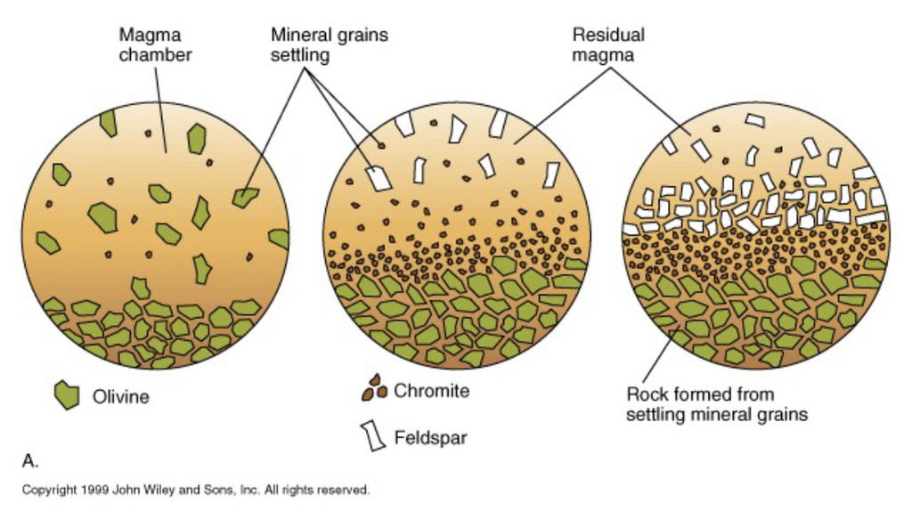

- **Mechanism Overview:** Gravity differentiation, also known as gravitational settling, occurs when early-formed crystals in a magma chamber are denser than the remaining liquid and sink to the bottom due to gravity.
- **Process:** As the crystals form, they are separated from the melt. Over time, the accumulation of these dense crystals at the base of the magma chamber leads to a stratified magma body, where the bottom layers are rich in early-formed minerals, and the upper layers remain more evolved and less dense.
- **Result:** This process changes the composition of the magma, leading to different rock types forming from the same magma as it cools, with dense mafic minerals forming at the base and felsic minerals at the top

# Fractional Crystallization (2)

## 2. Filter Pressing

- **Mechanism Overview:** Filter pressing occurs in the later stages of crystallization, when crystals become tightly packed and the remaining liquid is squeezed out from between them due to pressure exerted by the overlying rock or other forces.
- **Process:** This mechanism forces the melt out, leaving behind a crystal-rich solid. The expelled liquid moves to new areas where it may cool and crystallize separately from the original magma.
- **Result:** Filter pressing leads to chemical differentiation, as the remaining liquid is usually more evolved (richer in incompatible elements) than the original magma
- Filter-pressing has been used to explain the formation of monomineralic rocks or rocks with an apparently unusual mineralogical and chemical composition—e.g., anorthosite.

# Fractional Crystallization (3)

## 3. Flowage Differentiation or Flow Segregation

- **Mechanism Overview:** Flowage differentiation occurs when crystals are physically separated from the magma due to the flow of the magma through fractures or narrow channels. Lighter crystals may be carried along with the flowing magma, while heavier ones may settle out.
- **Process:** During the movement of magma, crystals with different densities and shapes are segregated, leading to zones with distinct mineral compositions.
- **Result:** This creates a heterogeneous magma body with different regions evolving in distinct ways, further contributing to the diversity of igneous rocks formed from a single magma source

# Liquid Immiscibility

## Definition and Overview

- Liquid Immiscibility: A process where a homogeneous magma separates into two or more immiscible (non-mixing) liquid phases.
- Occurs under specific conditions where chemical or physical factors prevent certain components of the melt from mixing.

## Mechanism

- As magma cools and its chemical composition changes, certain elements or compounds may become incompatible, leading to the formation of separate liquid phases.
- Example: Silicate melt and sulfide melt can separate, each with distinct chemical properties.

## Impact on Magma Evolution

- Each immiscible liquid phase evolves separately, contributing to the formation of different rock types.
- Result: The evolution of the magma is significantly altered, producing diverse compositions in the resulting rocks.

# Magma Mixing

## Definition and Overview

- Magma Mixing: The process where two or more magmas from different sources or stages of evolution mix together in a magma chamber, forming a hybrid magma.
- Occurs when distinct magmas come into contact due to:
  - Injection of fresh magma into a chamber.
  - Tectonic activity bringing different magma bodies together.

## Mechanism

- Mixing can occur between magmas with different temperatures, viscosities, and compositions.
- The process can be incomplete, resulting in a heterogeneous magma with varying mineral compositions or textures.

## Impact on Magma Evolution

- Results in intermediate magma compositions.
- Common in both intrusive and volcanic settings.
- Example: Andesitic magmas often form from the mixing of basaltic and rhyolitic magmas.

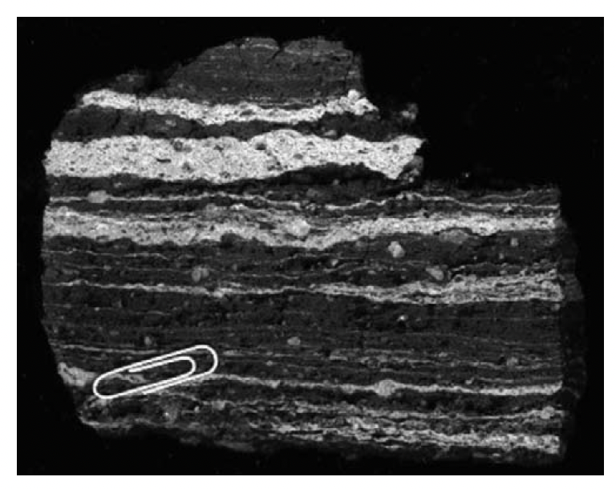

Commingled basaltic and rhyolitic magmas, Mt. McLoughlin, Oregon. Sample courtesy Stan Mertzman, Source: Winter, J. (2014)

# Magmatic Assimilation (Contamination)

## Definition and Overview

- Magmatic Assimilation: A process where magma incorporates and melts surrounding country rock (host rock), changing its composition.
  - Occurs when magma interacts with the rocks it intrudes into, leading to contamination of the original magma.

## Mechanism

- As hot magma rises, it can melt and assimilate fragments of the country rock.
  - This process introduces new chemical elements into the magma, altering its composition.
  - The extent of assimilation depends on factors like temperature, magma composition, and the amount of assimilated material.

## Impact on Magma Evolution

- Assimilation changes the chemical composition of the magma, potentially making it more felsic or introducing unique mineral compositions.
  - Can lead to xenoliths, which are pieces of unassimilated rock within an igneous body.

# Summary

- Magma Evolution: The process by which magma changes in composition as it cools and interacts with surrounding materials.

## Key Processes

1. Fractional Crystallization: Early-formed minerals are removed from the melt, changing the magma’s composition.
2. Liquid Immiscibility: Magma separates into two immiscible liquids, leading to diverse rock types.
3. Magma Mixing: Different magmas mix, forming hybrid compositions.
4. Contamination (Assimilation): Magma incorporates surrounding rocks, altering its composition.

## Impact on Igneous Rock Formation

- These processes influence the diversity of igneous rocks found in both intrusive plutonic settings and volcanic environments.
  - Examples: Andesites (magma mixing), granites (assimilation), and basalt (fractional crystallization).